# İstanbul Genelinde Seçim Sonuçları

secimler R paketi otomatik raporlama

2017-02-23

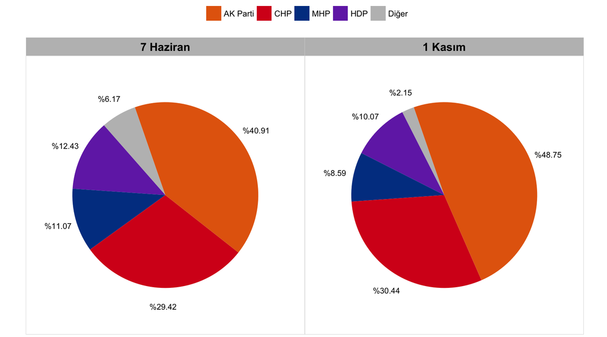

7 Haziran ve 1 Kasım 2015 genel seçimlerinin oy oranı bazında karşılaştırması.

# 7 Haziran 2015 Genel Seçimi Özet Bilgiler

İstanbul ilinde bu seçimde 3 seçim bölgesi 39 ilçe, 959 mahalle, 8 cezaevi ve toplamda 27.893 seçim sandığı bulunmaktadır. İl içerisinde toplam 10.231.703 kayıtlı seçmen bulunmaktadır. 8.832.058 seçmen oy kullanmış, geçerli oy sayısı ise 8.295.578 olmuştur. Seçime katılım oranı %86,32 olarak gerçekleşmiştir.

Toplam sonuçlarda AK Parti %40,91, CHP %29,42, MHP %11,07, HDP %12,43 ve diğer partiler ile bağımsızlar %6,17 oy oranına sahip olmuşlardır. İstanbul, 81 il arasından, partilerin kendi içindeki oy oranları sıralamalarına göre AK Parti’nin 45, CHP’nin 18, MHP’nin 65 ve HDP’nin 23. sıradaki ili olmuştur.[^1]

İstanbul 1. bölge Adalar, Ataşehir, Beykoz, Çekmeköy, Kadıköy, Kartal, Maltepe, Pendik, Sancaktepe, Şile, Sultanbeyli, Tuzla, Ümraniye ve Üsküdar ilçelerini kapsamaktadır.Bu bölgede 14 ilçe, 364 mahalle, 4 cezaevi ve toplamda 10.055 seçim sandığı bulunmaktadır. Seçim bölgesi içerisinde toplam 3.682.297 kayıtlı seçmen bulunmaktadır. 3.204.244 seçmen oy kullanmış, geçerli oy sayısı ise 3.036.754 olmuştur. Seçime katılım oranı %87,02 olarak gerçekleşmiştir.

Toplam sonuçlarda AK Parti %40,58, CHP %32,02, MHP %10,54, HDP %10,57 ve diğer partiler ile bağımsızlar %6,29 oy oranına sahip olmuşlardır.

İstanbul 2. bölge Bayrampaşa, Beşiktaş, Beyoğlu, Esenler, Eyüp, Fatih, Gaziosmanpaşa, Kağıthane, Sarıyer, Şişli, Sultangazi ve Zeytinburnu ilçelerini kapsamaktadır.Bu bölgede 12 ilçe, 306 mahalle, 1 cezaevi ve toplamda 8.318 seçim sandığı bulunmaktadır. Seçim bölgesi içerisinde toplam 3.052.377 kayıtlı seçmen bulunmaktadır. 2.616.876 seçmen oy kullanmış, geçerli oy sayısı ise 2.442.642 olmuştur. Seçime katılım oranı %85,73 olarak gerçekleşmiştir.

Toplam sonuçlarda AK Parti %42,75, CHP %27,66, MHP %11,26, HDP %12,33 ve diğer partiler ile bağımsızlar %6 oy oranına sahip olmuşlardır.

İstanbul 3. bölge Arnavutköy, Avcılar, Bağcılar, Bahçelievler, Bakırköy, Başakşehir, Beylikdüzü, Büyükçekmece, Çatalca, Esenyurt, Güngören, Küçükçekmece ve Silivri ilçelerini kapsamaktadır.Bu bölgede 13 ilçe, 289 mahalle, 3 cezaevi ve toplamda 9.520 seçim sandığı bulunmaktadır. Seçim bölgesi içerisinde toplam 3.497.029 kayıtlı seçmen bulunmaktadır. 3.010.938 seçmen oy kullanmış, geçerli oy sayısı ise 2.816.182 olmuştur. Seçime katılım oranı %86,1 olarak gerçekleşmiştir.

Toplam sonuçlarda AK Parti %39,68, CHP %28,12, MHP %11,49, HDP %14,51 ve diğer partiler ile bağımsızlar %6,2 oy oranına sahip olmuşlardır.

İl içerisinde sandık bazında partilere oy oranı dağılımı aşağıdaki grafikte gösterilmiştir. Kutu grafiğini yorumlamak için orta çizgi ortanca (medyan), alt ve üst çizgiler sırasıyla %25 ve %75lik dilimler ve noktalar da uç değerleri (outlier) göstermektedir. *(Örneğin bir partinin grafiğinin orta çizgisi %40 değerindeyse, sandıkların yarısında %40 ve üzeri, diğer yarısında ise %40 altı oy oranı var demektir.)*

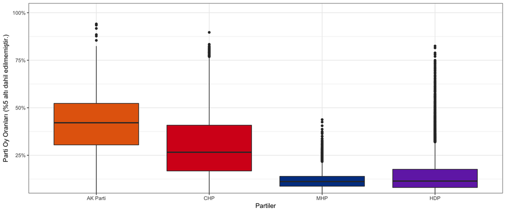

7 Haziran seçimlerinde partilerin seçim çevrelerinden aldıkları oy oranları kutu grafiği.

# 1 Kasım 2015 Genel Seçimi Özet Bilgiler

İstanbul ilinde bu seçimde 3 seçim bölgesi 39 ilçe, 959 mahalle, 8 cezaevi ve toplamda 28.053 seçim sandığı bulunmaktadır. İl içerisinde toplam 10.312.538 kayıtlı seçmen bulunmaktadır. 9.093.756 seçmen oy kullanmış, geçerli oy sayısı ise 8.989.092 olmuştur. Seçime katılım oranı %88,18 olarak gerçekleşmiştir.

Toplam sonuçlarda AK Parti %48,75, CHP %30,44, MHP %8,59, HDP %10,07 ve diğer partiler ile bağımsızlar %2,15 oy oranına sahip olmuşlardır. İstanbul, 81 il arasından, partilerin kendi içindeki oy oranları sıralamalarına göre AK Parti’nin 48, CHP’nin 19, MHP’nin 65 ve HDP’nin 23. sıradaki ili olmuştur.[^2]

İstanbul 1. bölge Adalar, Ataşehir, Beykoz, Çekmeköy, Kadıköy, Kartal, Maltepe, Pendik, Sancaktepe, Şile, Sultanbeyli, Tuzla, Ümraniye ve Üsküdar ilçelerini kapsamaktadır.Bu bölgede 14 ilçe, 364 mahalle, 4 cezaevi ve toplamda 10.129 seçim sandığı bulunmaktadır. Seçim bölgesi içerisinde toplam 3.718.621 kayıtlı seçmen bulunmaktadır. 3.308.005 seçmen oy kullanmış, geçerli oy sayısı ise 3.271.687 olmuştur. Seçime katılım oranı %88,96 olarak gerçekleşmiştir.

Toplam sonuçlarda AK Parti %47,57, CHP %33,02, MHP %8,64, HDP %8,61 ve diğer partiler ile bağımsızlar %2,16 oy oranına sahip olmuşlardır.

İstanbul 2. bölge Bayrampaşa, Beşiktaş, Beyoğlu, Esenler, Eyüp, Fatih, Gaziosmanpaşa, Kağıthane, Sarıyer, Şişli, Sultangazi ve Zeytinburnu ilçelerini kapsamaktadır.Bu bölgede 12 ilçe, 306 mahalle, 1 cezaevi ve toplamda 8.319 seçim sandığı bulunmaktadır. Seçim bölgesi içerisinde toplam 3.059.084 kayıtlı seçmen bulunmaktadır. 2.679.038 seçmen oy kullanmış, geçerli oy sayısı ise 2.649.114 olmuştur. Seçime katılım oranı %87,58 olarak gerçekleşmiştir.

Toplam sonuçlarda AK Parti %51,21, CHP %28,6, MHP %8,04, HDP %9,88 ve diğer partiler ile bağımsızlar %2,27 oy oranına sahip olmuşlardır.

İstanbul 3. bölge Arnavutköy, Avcılar, Bağcılar, Bahçelievler, Bakırköy, Başakşehir, Beylikdüzü, Büyükçekmece, Çatalca, Esenyurt, Güngören, Küçükçekmece ve Silivri ilçelerini kapsamaktadır.Bu bölgede 13 ilçe, 289 mahalle, 3 cezaevi ve toplamda 9.605 seçim sandığı bulunmaktadır. Seçim bölgesi içerisinde toplam 3.534.833 kayıtlı seçmen bulunmaktadır. 3.106.713 seçmen oy kullanmış, geçerli oy sayısı ise 3.068.291 olmuştur. Seçime katılım oranı %87,89 olarak gerçekleşmiştir.

Toplam sonuçlarda AK Parti %47,88, CHP %29,28, MHP %9,03, HDP %11,78 ve diğer partiler ile bağımsızlar %2,03 oy oranına sahip olmuşlardır.

İl içerisinde sandık bazında partilere oy oranı dağılımı aşağıdaki grafikte gösterilmiştir. Kutu grafiğini yorumlamak için orta çizgi ortanca (medyan), alt ve üst çizgiler sırasıyla %25 ve %75lik dilimler ve noktalar da uç değerleri (outlier) göstermektedir. *(Örneğin bir partinin grafiğinin orta çizgisi %40 değerindeyse, sandıkların yarısında %40 ve üzeri, diğer yarısında ise %40 altı oy oranı var demektir.)*

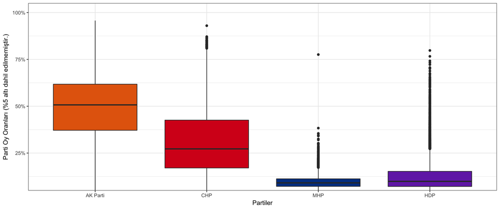

1 Kasım seçimlerinde partilerin seçim çevrelerinden aldıkları oy oranları kutu grafiği.

# Oy Kaymaları

7 Haziran ve 1 Kasım arasında partiler arasında oy kaymaları yaşanmıştır. Bu oy kaymaları seçim birimi bazındaki oy oranı değişimlerinin incelenmesi sonucu hesaplanmaktadır. Aşağıdaki tablolarda partiler arasındaki oy kaymaları verilmektedir. Tablolardaki oy kaymalarını incelerken lütfen aşağıdaki maddelere dikkat ediniz.

- Oy kaymaları satırdan sütuna okunmalıdır.
- Oy kaymaları puan bazındadır. Örneğin MHP’den AK Parti’ye %10 bir kayma; MHP’nin oylarının %10’unu değil, bütün oyların bir önceki seçimde MHP’ye ait olan %10luk kesimini belirtmektedir.
- Partilerin farklı sandıklarda oy oranları farklı şekillerde değiştiğinden iki partiden de birbirlerine oy kayması mümkün olabilir. Net oy kayması ayrı bir tabloda verilmiştir.
- Partiler arasında zincir olarak oy kayması yaşanmış olabilir. Örneğin MHP’den CHP’ye net oy kayması yaşanırken, CHP’den de AK Parti’ye net oy kayması yaşanmış olabilir.

Partiler arasındaki oy oranı kaymaları.

|  | AK Parti | CHP | MHP | HDP | Diğer |
| --- | --- | --- | --- | --- | --- |
| AK Parti | 0 | %0 | %0 | %0 | %0 |
| CHP | %0.1 | 0 | %0 | %0 | %0 |
| MHP | %2.17 | %0.35 | 0 | %0 | %0 |
| HDP | %1.99 | %0.33 | %0.01 | 0 | %0 |
| Diğer | %3.41 | %0.58 | %0.03 | %0 | 0 |

Partiler arasındaki net oy oranı kaymaları.

|  | AK Parti | CHP | MHP | HDP | Diğer |
| --- | --- | --- | --- | --- | --- |
| AK Parti | %0 | %0 | %0 | %0 | %0 |
| CHP | %0.1 | %0 | %0 | %0 | %0 |
| MHP | %2.17 | %0.35 | %0 | %0 | %0 |
| HDP | %1.99 | %0.33 | %0 | %0 | %0 |
| Diğer | %3.41 | %0.58 | %0.03 | %0 | %0 |

# İlçe Bazında Karşılaştırmalar

Aşağıdaki bilgilerde ilçe bazında özet grafikler bulunmaktadır. Bu grafiklerde her ilçenin toplam kayıtlı seçmen sayısı, geçerli oy sayısı, geçersiz oy sayısı ve barajı aşan partilerin (AK Parti, CHP, MHP ve HDP) oy oranları bulunmaktadır. İlçeler hakkında detaylı bilgi edinmek için ilçelerin kendi raporlarını inceleyebilirsiniz. *(Detaylı bilgi dökümanın sonunda yer almaktadır.)*

## Seçmen İstatistikleri

Kayıtlı seçmen sayısındaki değişim en yüksek oranda Sancaktepe (+%3.71) ilçesinde ve en düşük oranda Kadıköy (-%2.18) ilçesinde görülmektedir. Seçime katılım oranında değişim ise en yüksek oranda Güngören (+%2.3) ilçesinde ve en düşük oranda Adalar (-%1.29) ilçesinde görülmektedir.

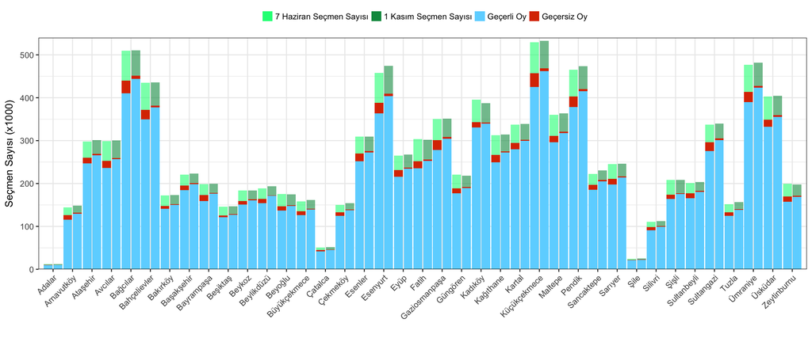

İlçelerin kayıtlı seçmen, geçerli ve geçersiz oy sayıları.

## Parti Oy Oranları

### AK Parti

AK Parti, 7 Haziran seçimlerinde İstanbul ilçeleri arasında en yüksek oy oranını Sultanbeyli (%56.99), en düşük oy oranını Beşiktaş (%15.25) ilçelerinde görmüştür. 1 Kasım seçimlerinde ise en yüksek oy oranını Sultanbeyli (%66.93), en düşük oy oranını Beşiktaş (%18.17) ilçelerinde görmüştür. Parti bütün ilçelerde oy oranlarını yükseltmiştir. Puan bazında en büyük yükseliş Arnavutköy ilçesinde (+%12.85) görülmektedir.

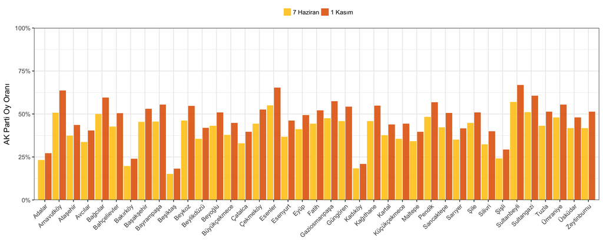

AK Parti’nin ilçelerde aldığı oy oranları.

### CHP

CHP, 7 Haziran seçimlerinde İstanbul ilçeleri arasında en yüksek oy oranını Beşiktaş (%58.67), en düşük oy oranını Sultanbeyli (%7.78) ilçelerinde görmüştür. 1 Kasım seçimlerinde ise en yüksek oy oranını Beşiktaş (%62.9), en düşük oy oranını Sultanbeyli (%7.87) ilçelerinde görmüştür. Puan bazında en büyük yükseliş Bakırköy ilçesinde (+%4.95) görülmektedir. Puan bazında en büyük düşüş ise Arnavutköy ilçesinde (-%0.31) görülmektedir.

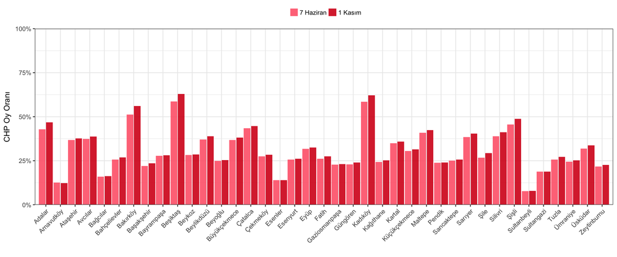

CHP’nin ilçelerde aldığı oy oranları.

### MHP

MHP, 7 Haziran seçimlerinde İstanbul ilçeleri arasında en yüksek oy oranını Şile (%16.93), en düşük oy oranını Sultangazi (%7.7) ilçelerinde görmüştür. 1 Kasım seçimlerinde ise en yüksek oy oranını Şile (%12.19), en düşük oy oranını Sultangazi (%5.24) ilçelerinde görmüştür. Parti hiçbir ilçede oy oranını yükseltememiştir. Puan bazında en büyük düşüş Çatalca ilçesinde (-%4.8) görülmektedir.

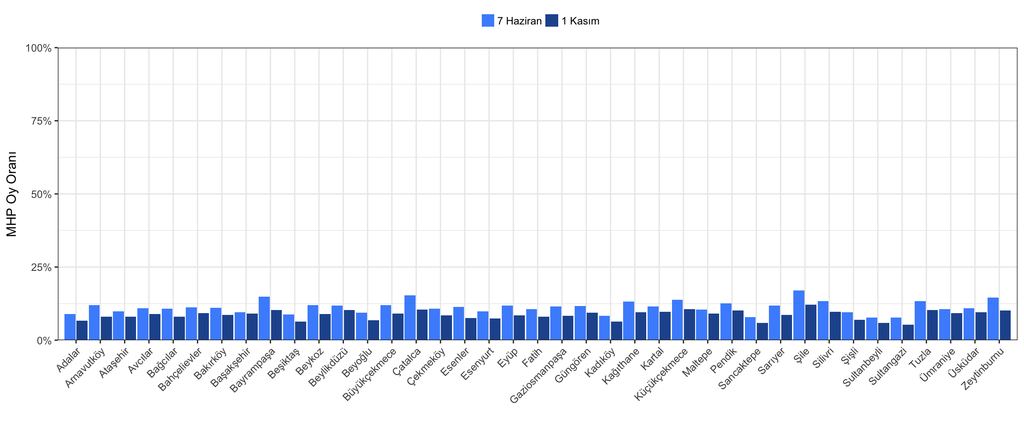

MHP’nin ilçelerde aldığı oy oranları.

### HDP

HDP, 7 Haziran seçimlerinde İstanbul ilçeleri arasında en yüksek oy oranını Esenyurt (%22.61), en düşük oy oranını Çatalca (%3.34) ilçelerinde görmüştür. 1 Kasım seçimlerinde ise en yüksek oy oranını Esenyurt (%18.53), en düşük oy oranını Çatalca (%2.73) ilçelerinde görmüştür. Parti hiçbir ilçede oy oranını yükseltememiştir. Puan bazında en büyük düşüş Arnavutköy ilçesinde (-%4.66) görülmektedir.

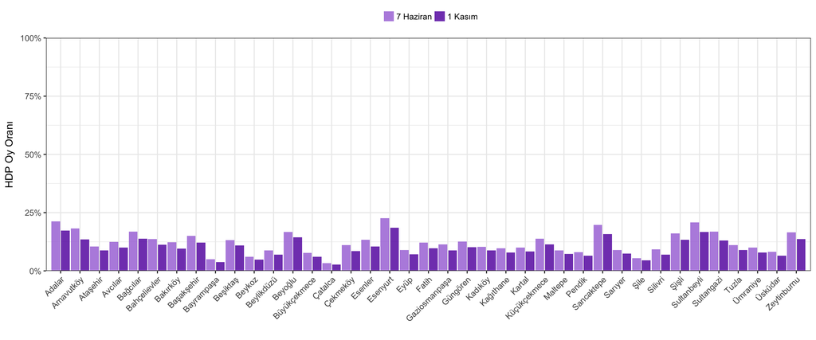

HDP’nin ilçelerde aldığı oy oranları.

# Bilinmesi Gerekenler

- Bu döküman otomatik olarak oluşturulmuştur.
- Dökümanın amacı R ile veri analizi, görselleştirme ve otomatik raporlama konusunda bir eğitim örneği oluşturmaktır.
- Bu dökümanı oluşturmakta kullanılan veriler 7 Haziran ve 1 Kasım’a ait sandık bazında seçim sonucu verilerinden oluşmaktadır. Veriler TÜİK vasıtasıyla YSK kesin seçim sonuçlarından elde edilmiştir.
- Veriler veya hesaplamalarda yanlışlıklar olabilir. Veriler ve analizlerle ilgili herhangi bir sorumluluk kabul edilmemektedir.
- İlgili veri setleri ve analizlere `secimler` R paketi vasıtasıyla ulaşılabilir. Paket hala geliştirme aşamasında olup sürekli güncellenmektedir. https://github.com/berkorbay/secimler adresinden pakete ulaşılabilir ve yükleme talimatları görülebilir.
- Paketin yazarına (Berk Orbay) http://berkorbay.me adresinden ulaşabilirsiniz.
[^1]: Örneğin, AK Parti 44 ilde daha yüksek, 36 ilde ise daha düşük oy oranı görmüştür.
[^2]: Örneğin, AK Parti 47 ilde daha yüksek, 33 ilde ise daha düşük oy oranı görmüştür.